# Bluefish wind analysis

Abigail Tyrell

20 Apr 2022

# 1 Introduction

This wind analysis was inspired by Munch and Conover (2000), who found a correlation between wind speed and coastwide YOY index. The wind measurements used are described below:

> The NOAA environmental buoy array provided environmental data from 1970 to 1992. Buoys collected hourly records of windspeed and wind direction at a height of 10 m, and surface temperature at a depth of 1.5 m. Data were examined from a total of 34 buoys in fixed locations throughout the region from Cape Fear to the Gulf of Maine and extending from nearshore to beyond the shelf break. Buoy locations are reported in Munch (1997).

Spring-spawned YOY were apparently characterized as fish between 13-27cm in length in the autumn bottom trawl, but “A complete set of length-frequency distributions and cohort designations is presented in Munch (1997)”.

And the observed correlation is described:

> A strong relationship existed between offshore wind and recruitment. Using north (n) and east (e) windstress components from NOAA buoys near the edge of the shelf of the Mid-Atlantic Bight, the model ln(c.p.u.e.) = -16.5 n - 12.8 e + 0.59 (p<0.05) explained 36% of the variance in spring cohort abundance in the SNE region

I am trying to obtain a copy of Munch (1997), which is a master’s thesis (Munch, S. B. 1997. Recruitment Dynamics of Bluefish, Pomatonus saltatrix, on the continental shelf from Cape Fear to Cape Cod, 1973–1995. M.S. Thesis. State University of New York at Stony Brook).

# 2 Determine relevant strata

## 2.1 What polygons to use?

Entire east coast:

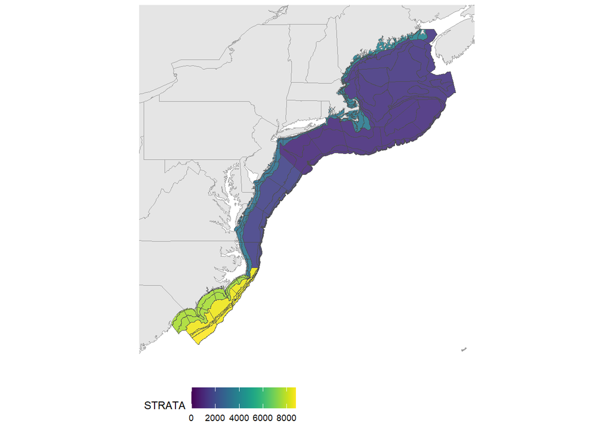

Inshore (ish) strata:

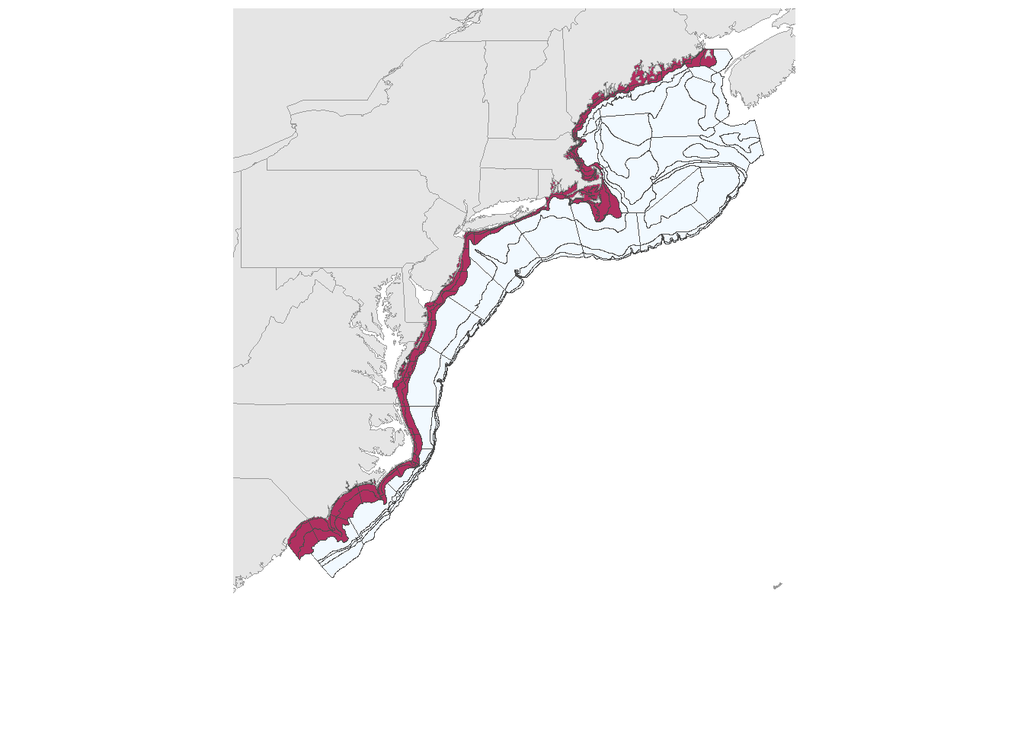

All strata south of ~ Cape Cod

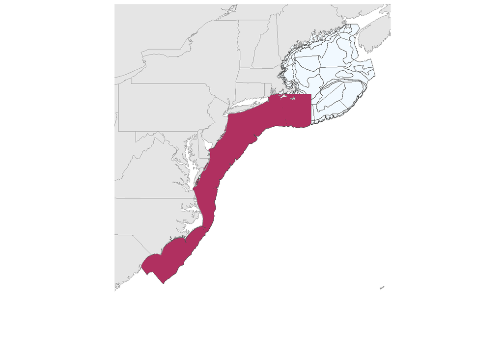

# 3 Daily data

## 3.1 Downloaded daily mean dataset (uwind, vwind) from NOAA PSL

Located in `data-raw` folder.

## 3.2 Extract mean wind by day

### 3.2.1 v wind

#### 3.2.1.1 Read in wind data

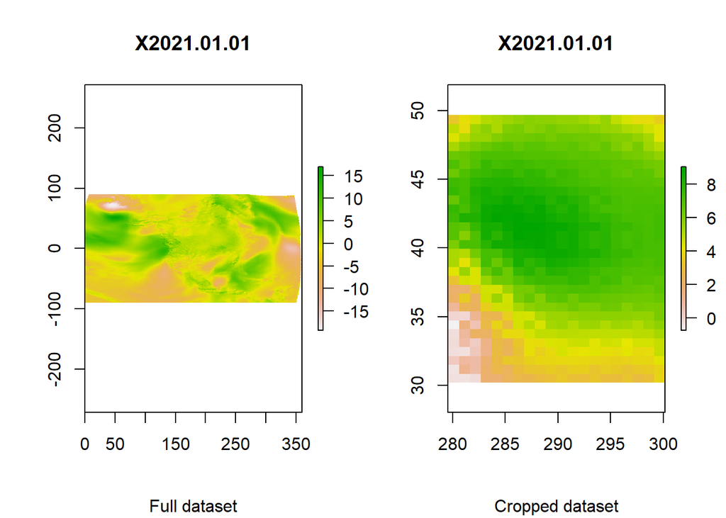

```r
# use ecopull function
devtools::install_github("kimberly-bastille/ecopull")
vwind <- ecopull::nc_to_raster(nc = here::here("data-raw/vwnd.10m.2021.nc"),
                               varname = "vwnd",
                               show_images = TRUE)
```

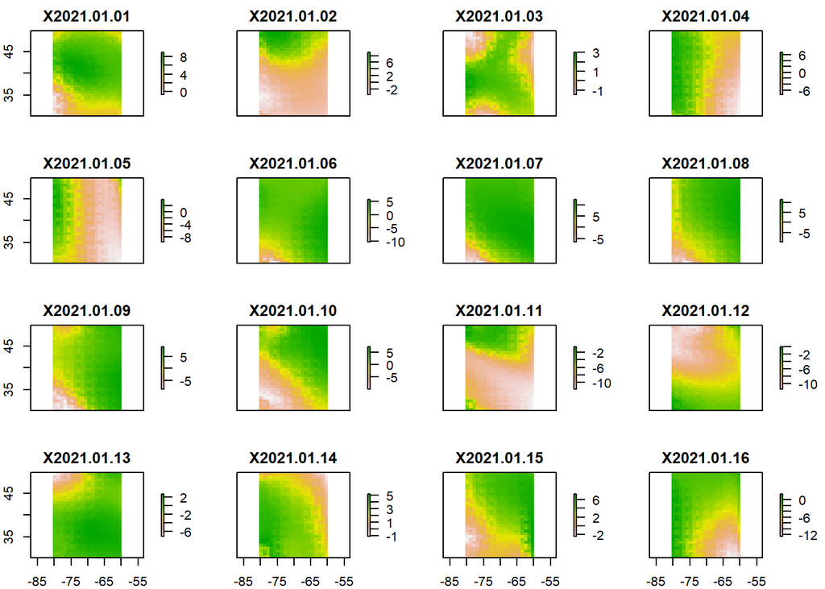

```r
vwind <- raster::rotate(vwind)
raster::plot(vwind)
```

#### 3.2.1.2 Mask to relevant strata

```r
m_vwind <- raster::mask(x = vwind,
                        mask = new_shape[new_shape$STRATA > 2000 &
                                           new_shape$STRATA < 8000,2])
mean(m_vwind@data@values, na.rm = TRUE)
```

```
## [1] -0.9522257
```

```r
m_vwind[[1]]
```

```
## class      : RasterLayer
## dimensions : 30, 20, 600  (nrow, ncol, ncell)
## resolution : 1.031519, 0.6498195  (x, y)
## extent     : -80.45845, -59.82808, 30.21661, 49.71119  (xmin, xmax, ymin, ymax)
## crs        : +proj=longlat +lat_0=40 +lon_0=-77 +x_0=0 +y_0=0 +datum=NAD83 +no_defs +ellps=GRS80 +towgs84=0,0,0
## source     : memory
## names      : X2021.01.01
## values     : 0.747654, 8.843357  (min, max)
## time       : 2021-01-01
```

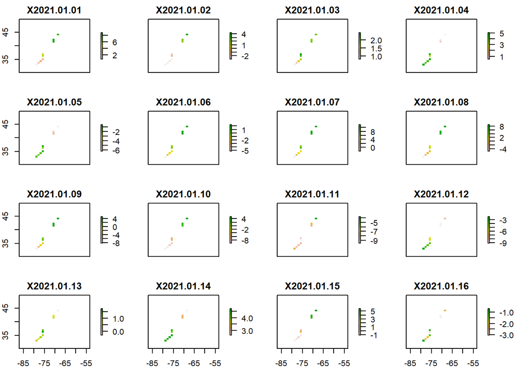

```r
raster::plot(m_vwind)
```

##### 3.2.1.2.1 Plot over map

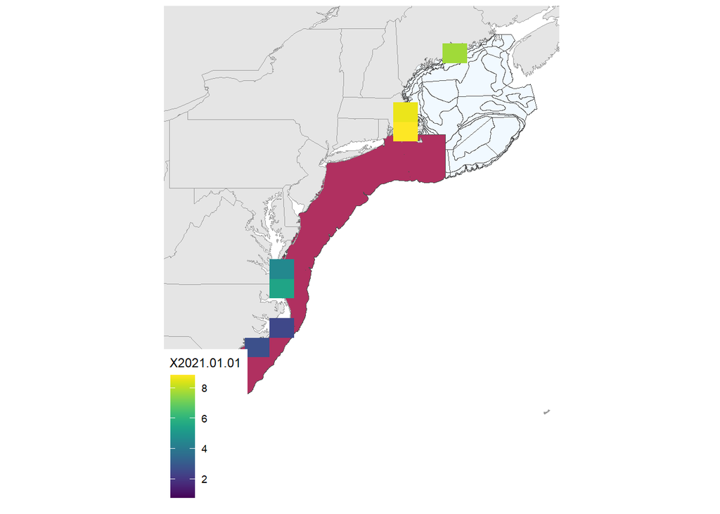

Seems like the existing strata are too small, try masking to more strata.

#### 3.2.1.3 Mask to different strata

```r
m_vwind2 <- raster::mask(x = vwind,
                        mask = large_geom)
mean(m_vwind2@data@values, na.rm = TRUE)
```

```
## [1] -0.9731909
```

```r
m_vwind2[[1]]
```

```
## class      : RasterLayer
## dimensions : 30, 20, 600  (nrow, ncol, ncell)
## resolution : 1.031519, 0.6498195  (x, y)
## extent     : -80.45845, -59.82808, 30.21661, 49.71119  (xmin, xmax, ymin, ymax)
## crs        : +proj=longlat +lat_0=40 +lon_0=-77 +x_0=0 +y_0=0 +datum=NAD83 +no_defs +ellps=GRS80 +towgs84=0,0,0
## source     : memory
## names      : X2021.01.01
## values     : 0.1705055, 8.967381  (min, max)
## time       : 2021-01-01
```

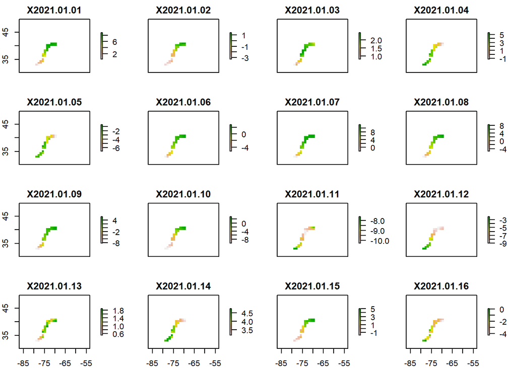

```r
raster::plot(m_vwind2)
```

##### 3.2.1.3.1 Plot over map

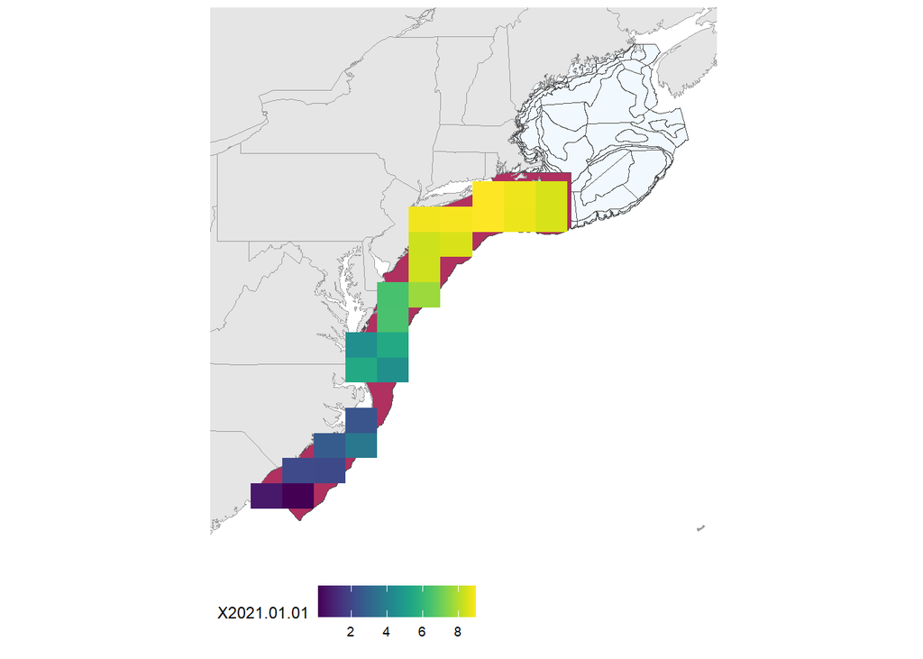

This seems like a better geometry.

### 3.2.2 u wind

#### 3.2.2.1 Read in wind data

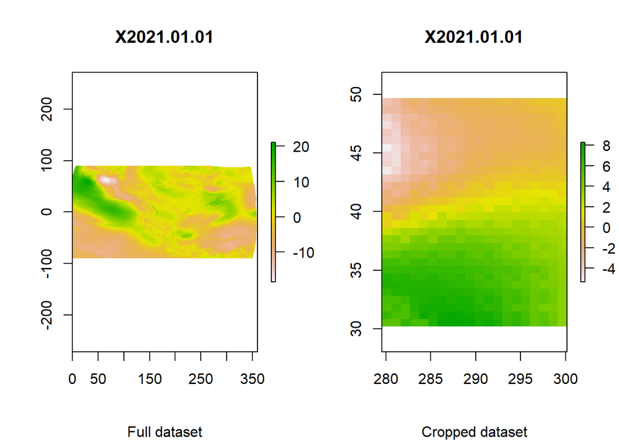

```r
# use ecopull function
devtools::install_github("kimberly-bastille/ecopull")
uwind <- ecopull::nc_to_raster(nc = here::here("data-raw/uwnd.10m.2021.nc"),
                               varname = "uwnd",
                               show_images = TRUE)
```

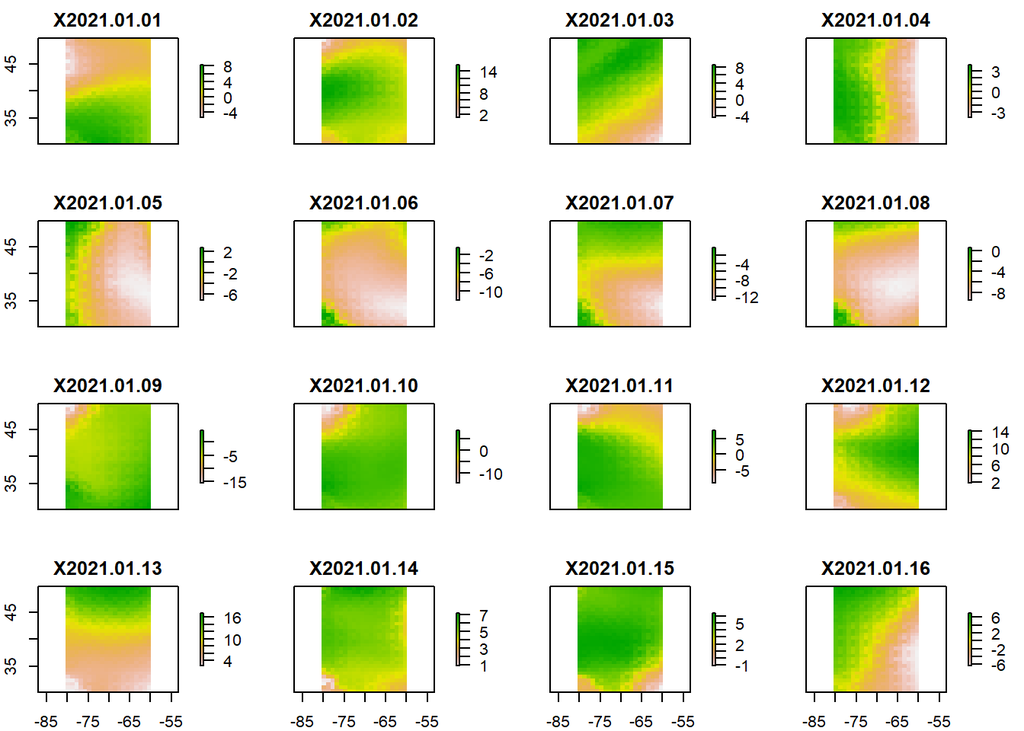

```r
uwind <- raster::rotate(uwind)
raster::plot(uwind)
```

#### 3.2.2.2 Mask to strata

```r
m_uwind2 <- raster::mask(x = uwind,
                        mask = large_geom)
mean(m_uwind2@data@values, na.rm = TRUE)
```

```
## [1] 1.321539
```

```r
m_uwind2[[1]]
```

```
## class      : RasterLayer
## dimensions : 30, 20, 600  (nrow, ncol, ncell)
## resolution : 1.031519, 0.6498195  (x, y)
## extent     : -80.45845, -59.82808, 30.21661, 49.71119  (xmin, xmax, ymin, ymax)
## crs        : +proj=longlat +lat_0=40 +lon_0=-77 +x_0=0 +y_0=0 +datum=NAD83 +no_defs +ellps=GRS80 +towgs84=0,0,0
## source     : memory
## names      : X2021.01.01
## values     : 1.038357, 7.00613  (min, max)
## time       : 2021-01-01
```

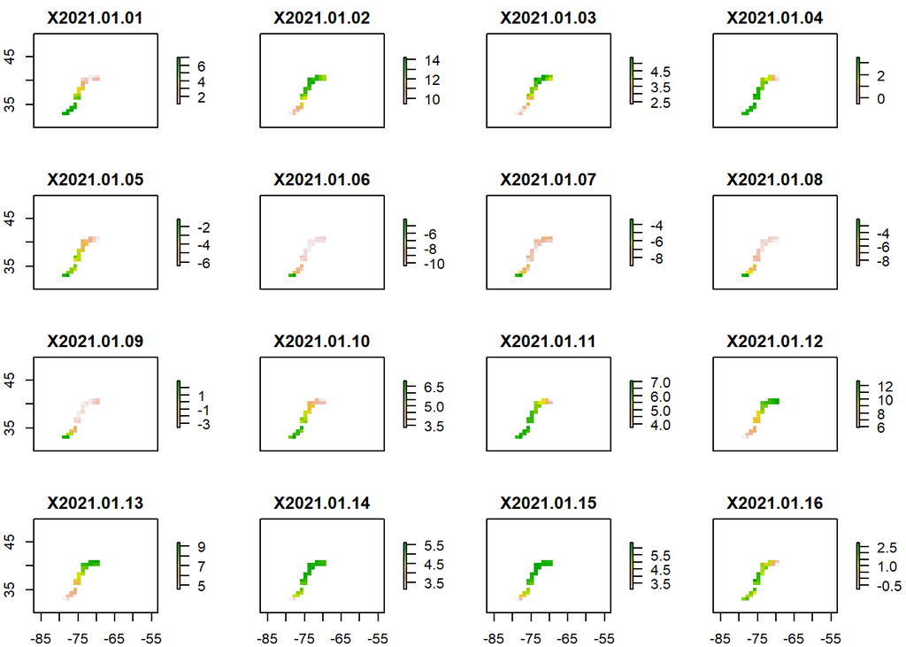

```r
raster::plot(m_uwind2)
```

##### 3.2.2.2.1 Plot over map

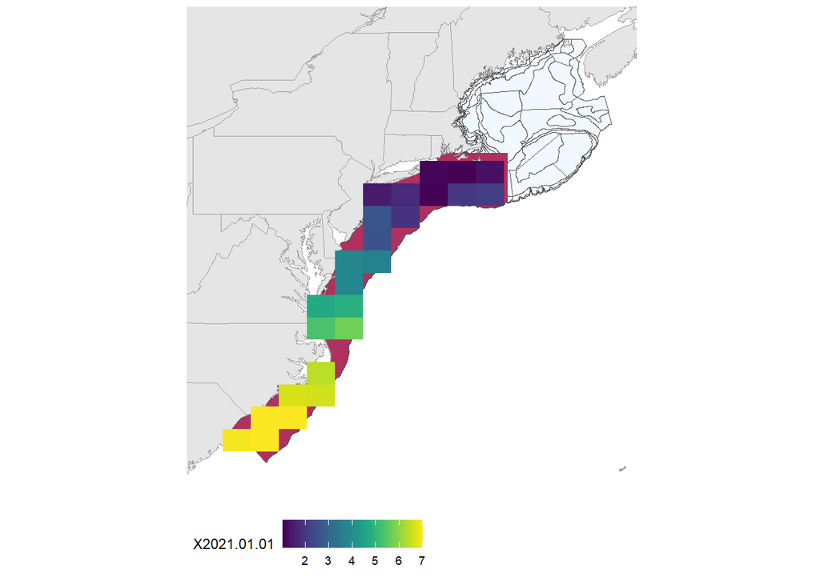

### 3.2.3 Calculate weekly mean u and v wind

#### 3.2.3.1 v wind

Break into north and south regions at 39N (approximately the bottom of NJ)

Positive v wind = wind is blowing to the north

```
##         names         mean_wind            min_wind          max_wind
## 1 X2021.01.01  8.67782974243164    8.32382583618164  8.96738052368164
## 2 X2021.01.02 0.727199292182922 -0.0607889890670776  1.43823444843292
## 3 X2021.01.03    2.053333568573      1.762610912323    2.250892162323
## 4 X2021.01.04 0.892561662197113   -1.19894230365753  2.63406562805176
## 5 X2021.01.05 -4.73075468540192   -6.87157487869263 -2.68505167961121
## 6 X2021.01.06  2.14590229988098    1.55810940265656  2.86865615844727
```

```
##         names          mean_wind          min_wind            max_wind
## 1 X2021.01.01   4.19205500284831 0.170505523681641    8.33652114868164
## 2 X2021.01.02  -2.03624478975932 -3.27465629577637 0.00757038593292236
## 3 X2021.01.03   1.81625674565633 0.796790599822998      2.449134349823
## 4 X2021.01.04   3.93146146138509  1.99344062805176    5.49441719055176
## 5 X2021.01.05  -1.92808553377787 -3.53368449211121  -0.494621992111206
## 6 X2021.01.06 -0.980953073501587 -5.24364852905273    1.50732815265656
```

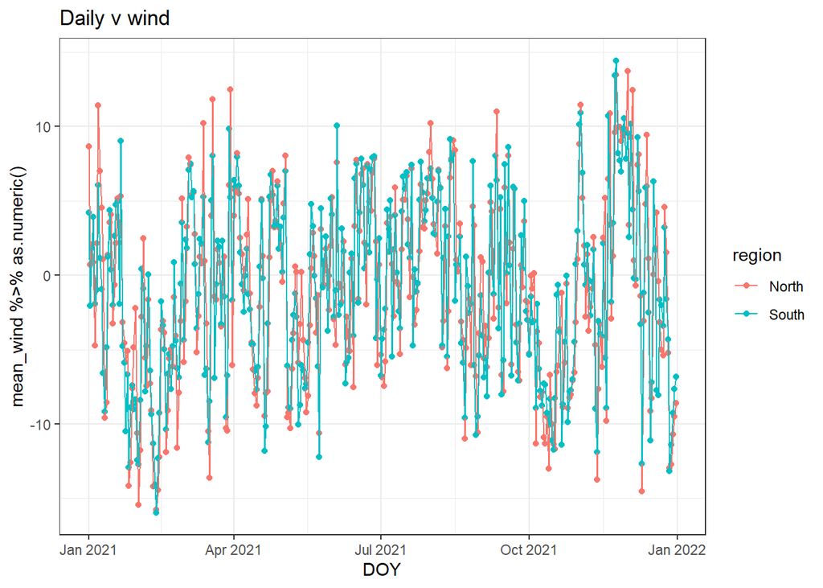

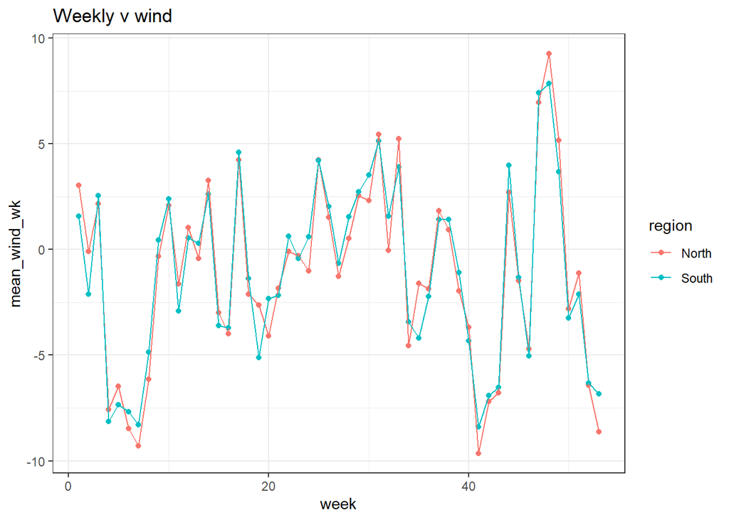

#### 3.2.3.2 u wind

Positive u wind = wind is blowing to the east

```
##         names         mean_wind           min_wind          max_wind
## 1 X2021.01.01  1.62507553100586   1.03835678100586  2.60866928100586
## 2 X2021.01.02  13.3995737075806   12.3858041763306  14.2393198013306
## 3 X2021.01.03  4.90297966003418   3.98139762878418  5.40229606628418
## 4 X2021.01.04  1.18881988525391 -0.510887145996094  2.53403472900391
## 5 X2021.01.05 -5.39001960754395  -6.41169929504395 -4.32380867004395
## 6 X2021.01.06 -10.1598304748535  -10.3247718811035 -9.93317031860352
```

```
##         names         mean_wind          min_wind          max_wind
## 1 X2021.01.01  5.45678126017253  2.56863021850586  7.00613021850586
## 2 X2021.01.02  11.8261691411336  9.40728950500488  13.8184213638306
## 3 X2021.01.03  3.47338981628418  2.34663200378418  4.80463981628418
## 4 X2021.01.04  3.07706858317057  2.32114410400391  3.48325347900391
## 5 X2021.01.05 -3.09281908671061 -4.70564460754395 -1.17439460754395
## 6 X2021.01.06 -8.94026629130046 -10.4019203186035  -4.1235990524292
```

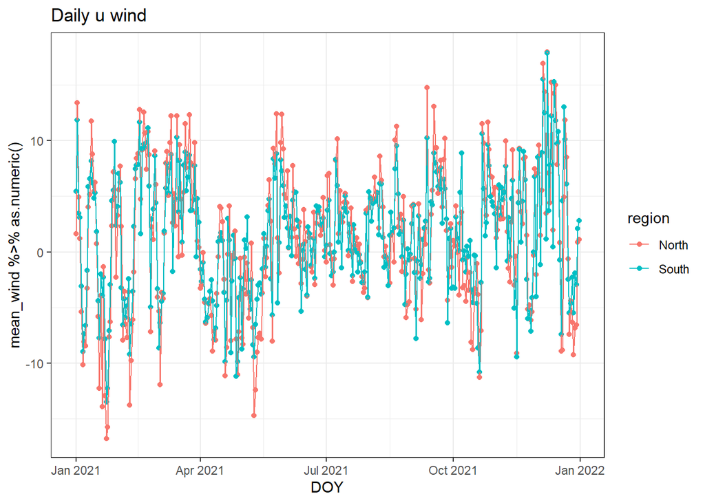

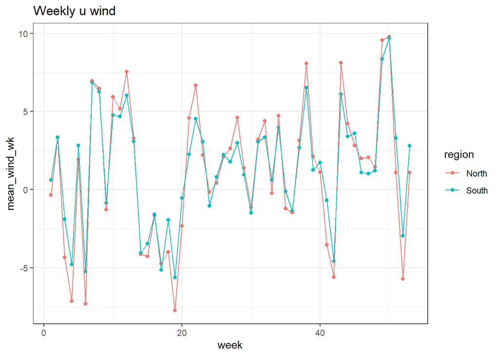

## 3.3 Calculate hypotenuse and angle by week

Angles/directions are probably not reliable yet - have to ground truth

| week | region | v_mean | u_mean | wind_magnitude | wind_blowing_to | angle | coast_angle | new_angle | longshore_wind | crossshore_wind | wind_blowing_to2 |
| --- | --- | --- | --- | --- | --- | --- | --- | --- | --- | --- | --- |
| 1 | North | 3.026 | -0.357 | 3.047 | northwest | -1.453 | 0.785 | 2.239 | 1.888 | 2.392 | up_coast towards_coast |
| 1 | South | 1.578 | 0.631 | 1.699 | northeast | 1.190 | 0.785 | -0.404 | 1.562 | 0.668 | down_coast away_coast |
| 2 | North | -0.094 | 3.338 | 3.339 | southeast | -0.028 | 0.785 | 0.814 | 2.293 | 2.427 | up_coast away_coast |
| 2 | South | -2.115 | 3.345 | 3.958 | southeast | -0.564 | 0.785 | 1.350 | 0.867 | 3.862 | up_coast away_coast |
| 3 | North | 2.150 | -4.333 | 4.837 | northwest | -0.461 | 0.785 | 1.247 | 1.539 | 4.586 | up_coast away_coast |
| 3 | South | 2.550 | -1.892 | 3.175 | northwest | -0.932 | 0.785 | 1.718 | 0.466 | 3.141 | up_coast towards_coast |
| 4 | North | -7.573 | -7.124 | 10.397 | southwest | 0.816 | 0.785 | -0.030 | 10.392 | 0.322 | down_coast away_coast |
| 4 | South | -8.147 | -4.776 | 9.444 | southwest | 1.041 | 0.785 | -0.255 | 9.139 | 2.381 | down_coast away_coast |
| 5 | North | -6.466 | 1.929 | 6.748 | southeast | -1.281 | 0.785 | 2.067 | 3.213 | 5.934 | up_coast towards_coast |
| 5 | South | -7.336 | 2.833 | 7.864 | southeast | -1.202 | 0.785 | 1.988 | 3.187 | 7.189 | up_coast towards_coast |
| 6 | North | -8.473 | -7.287 | 11.176 | southwest | 0.861 | 0.785 | -0.075 | 11.145 | 0.832 | down_coast away_coast |
| 6 | South | -7.683 | -5.222 | 9.290 | southwest | 0.974 | 0.785 | -0.188 | 9.126 | 1.738 | down_coast away_coast |
| 7 | North | -9.290 | 6.954 | 11.604 | southeast | -0.928 | 0.785 | 1.714 | 1.656 | 11.485 | up_coast towards_coast |
| 7 | South | -8.285 | 6.853 | 10.752 | southeast | -0.880 | 0.785 | 1.666 | 1.022 | 10.703 | up_coast towards_coast |
| 8 | North | -6.137 | 6.446 | 8.900 | southeast | -0.761 | 0.785 | 1.547 | 0.212 | 8.897 | up_coast away_coast |
| 8 | South | -4.867 | 6.264 | 7.933 | southeast | -0.661 | 0.785 | 1.447 | 0.980 | 7.872 | up_coast away_coast |
| 9 | North | -0.318 | -1.262 | 1.301 | southwest | 0.247 | 0.785 | 0.539 | 1.117 | 0.667 | up_coast away_coast |
| 9 | South | 0.433 | -0.853 | 0.957 | northwest | -0.470 | 0.785 | 1.256 | 0.296 | 0.910 | up_coast away_coast |
| 10 | North | 2.072 | 5.935 | 6.286 | northeast | 0.336 | 0.785 | 0.450 | 5.660 | 2.735 | up_coast away_coast |
| 10 | South | 2.387 | 4.765 | 5.329 | northeast | 0.464 | 0.785 | 0.322 | 5.055 | 1.687 | up_coast away_coast |
| 11 | North | -1.636 | 5.176 | 5.428 | southeast | -0.306 | 0.785 | 1.092 | 2.501 | 4.817 | up_coast away_coast |
| 11 | South | -2.914 | 4.683 | 5.516 | southeast | -0.557 | 0.785 | 1.343 | 1.246 | 5.373 | up_coast away_coast |
| 12 | North | 1.044 | 7.549 | 7.621 | northeast | 0.137 | 0.785 | 0.649 | 6.072 | 4.605 | up_coast away_coast |
| 12 | South | 0.535 | 6.021 | 6.045 | northeast | 0.089 | 0.785 | 0.697 | 4.635 | 3.881 | up_coast away_coast |
| 13 | North | -0.424 | 3.268 | 3.295 | southeast | -0.129 | 0.785 | 0.915 | 2.009 | 2.612 | up_coast away_coast |
| 13 | South | 0.299 | 3.083 | 3.097 | northeast | 0.097 | 0.785 | 0.689 | 2.391 | 1.968 | up_coast away_coast |
| 14 | North | 3.251 | -4.124 | 5.251 | northwest | -0.668 | 0.785 | 1.454 | 0.612 | 5.215 | up_coast away_coast |
| 14 | South | 2.623 | -4.036 | 4.813 | northwest | -0.576 | 0.785 | 1.362 | 0.998 | 4.708 | up_coast away_coast |
| 15 | North | -2.988 | -4.252 | 5.197 | southwest | 0.613 | 0.785 | 0.173 | 5.119 | 0.897 | up_coast away_coast |
| 15 | South | -3.605 | -3.462 | 4.998 | southwest | 0.806 | 0.785 | -0.020 | 4.997 | 0.100 | down_coast away_coast |

[output cut: 76 more lines]

### 3.3.1 Try plotting to see if things look correct

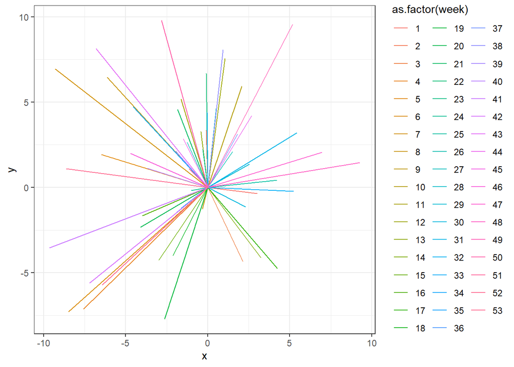

# 4 Monthly data

## 4.1 Extract mean wind by month

### 4.1.1 v wind

#### 4.1.1.1 Read in wind data

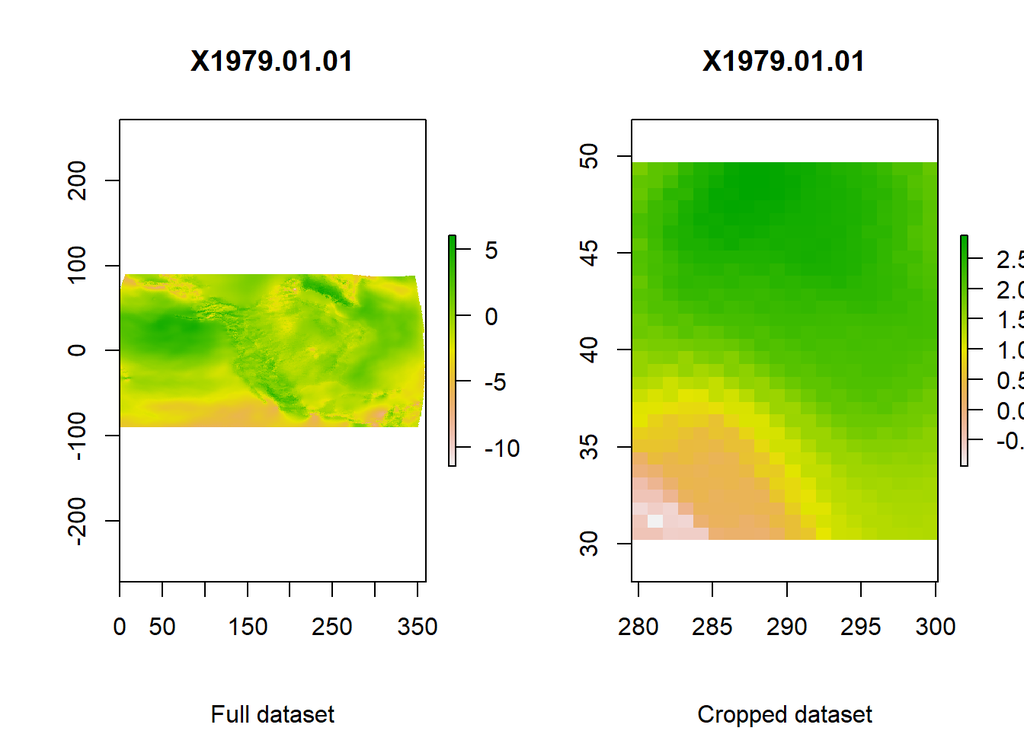

```r
# use ecopull function
vwind <- ecopull::nc_to_raster(nc = here::here("data-raw/vwnd.10m.mon.mean.nc"),
                               varname = "vwnd",
                               show_images = TRUE)
```

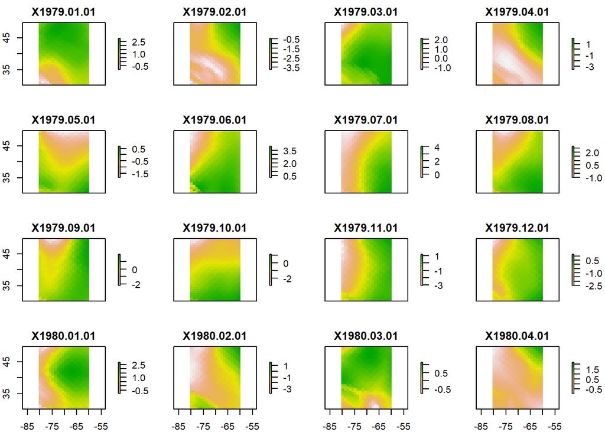

```r
vwind <- raster::rotate(vwind)
raster::plot(vwind)
```

#### 4.1.1.2 Mask to relevant strata

```r
m_vwind <- raster::mask(x = vwind,
                        mask = large_geom)
mean(m_vwind@data@values, na.rm = TRUE)
```

```
## [1] -0.1615039
```

```r
m_vwind[[1]]
```

```
## class      : RasterLayer
## dimensions : 30, 20, 600  (nrow, ncol, ncell)
## resolution : 1.031519, 0.6498195  (x, y)
## extent     : -80.45845, -59.82808, 30.21661, 49.71119  (xmin, xmax, ymin, ymax)
## crs        : +proj=longlat +lat_0=40 +lon_0=-77 +x_0=0 +y_0=0 +datum=NAD83 +no_defs +ellps=GRS80 +towgs84=0,0,0
## source     : memory
## names      : X1979.01.01
## values     : -0.188582, 2.251501  (min, max)
## time       : 1979-01-01
```

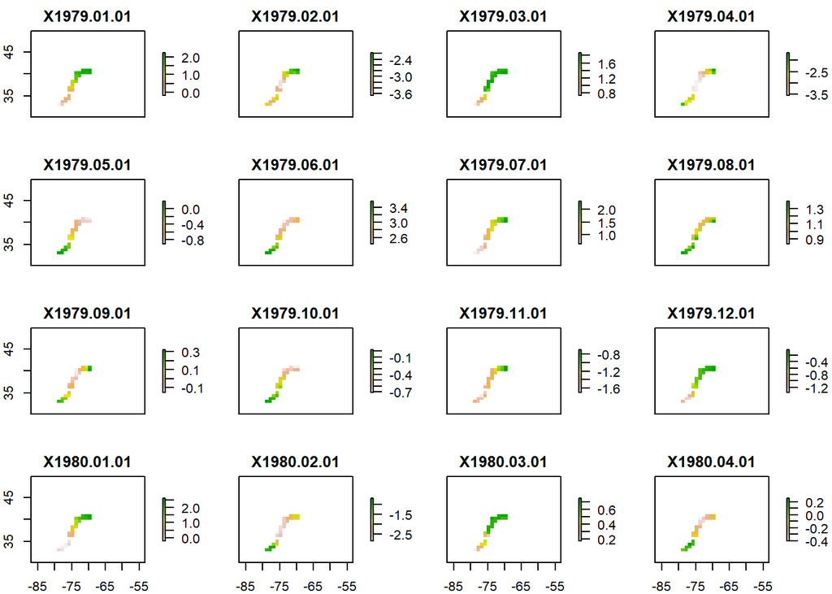

```r
raster::plot(m_vwind)
```

##### 4.1.1.2.1 Plot over map

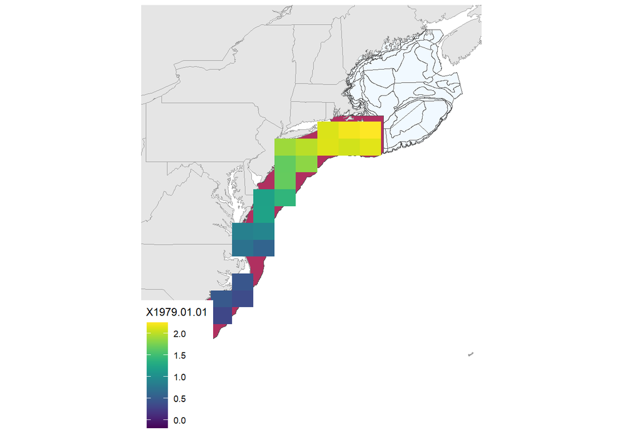

### 4.1.2 u wind

#### 4.1.2.1 Read in wind data

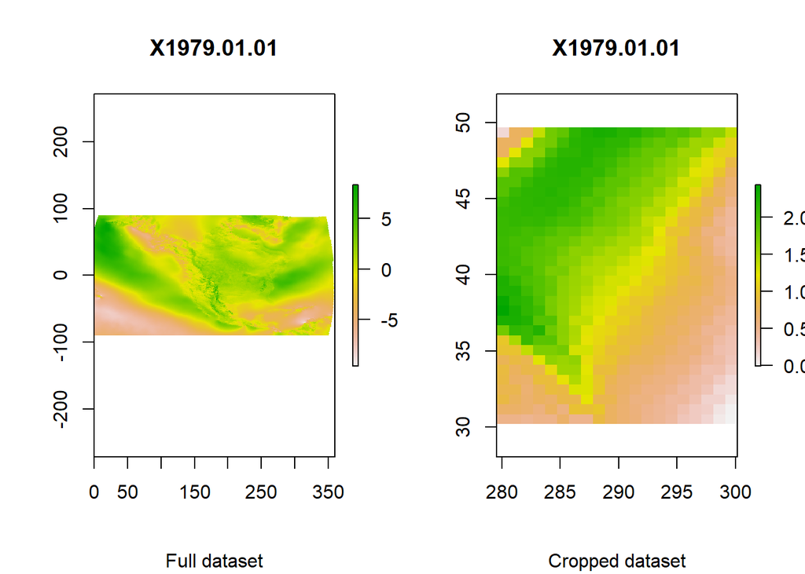

```r
# use ecopull function
uwind <- ecopull::nc_to_raster(nc = here::here("data-raw/uwnd.10m.mon.mean.nc"),
                               varname = "uwnd",
                               show_images = TRUE)
```

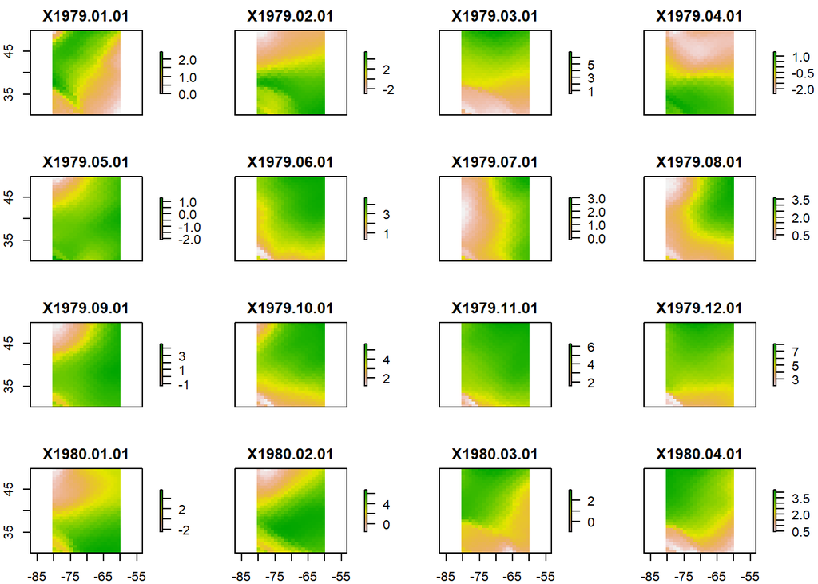

```r
uwind <- raster::rotate(uwind)
raster::plot(uwind)
```

#### 4.1.2.2 Mask to relevant strata

```r
m_uwind <- raster::mask(x = uwind,
                        mask = large_geom)
mean(m_uwind@data@values, na.rm = TRUE)
```

```
## [1] 2.585091
```

```r
m_uwind[[1]]
```

```
## class      : RasterLayer
## dimensions : 30, 20, 600  (nrow, ncol, ncell)
## resolution : 1.031519, 0.6498195  (x, y)
## extent     : -80.45845, -59.82808, 30.21661, 49.71119  (xmin, xmax, ymin, ymax)
## crs        : +proj=longlat +lat_0=40 +lon_0=-77 +x_0=0 +y_0=0 +datum=NAD83 +no_defs +ellps=GRS80 +towgs84=0,0,0
## source     : memory
## names      : X1979.01.01
## values     : 0.6709892, 1.908766  (min, max)
## time       : 1979-01-01
```

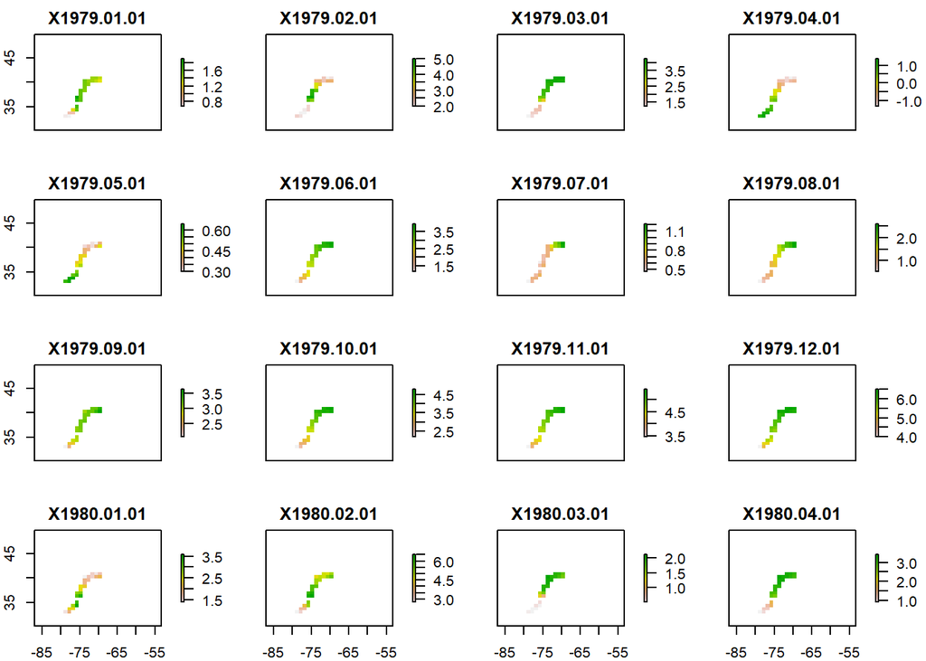

```r
raster::plot(m_uwind)
```

##### 4.1.2.2.1 Plot over map

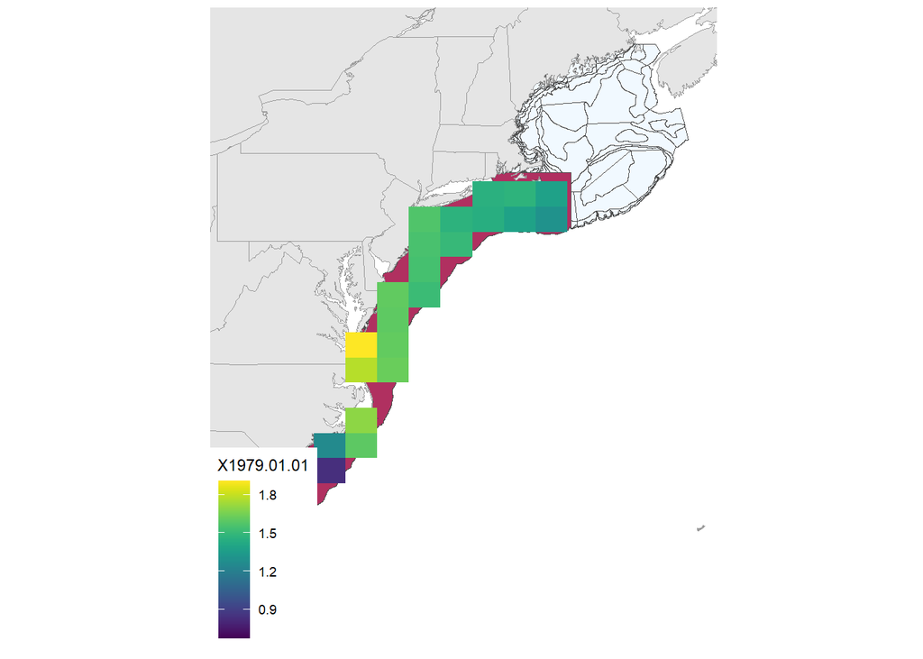

### 4.1.3 Calculate monthly mean u and v wind

#### 4.1.3.1 v wind

Break into north and south regions at 39N (approximately the bottom of NJ)

Positive v wind = wind is blowing to the north

```
##         names          mean_wind           min_wind           max_wind
## 1 X1979.01.01   2.03434200286865    1.6679892539978   2.25150108337402
## 2 X1979.02.01  -2.61082348823547  -3.20551514625549  -2.16903352737427
## 3 X1979.03.01   1.78748390674591   1.65858399868011   1.87497127056122
## 4 X1979.04.01  -2.72354888916016  -3.43132877349854  -1.65548253059387
## 5 X1979.05.01 -0.771568644046783 -0.905924737453461 -0.616295218467712
## 6 X1979.06.01   2.62528488636017   2.42658042907715   2.83055186271667
```

```
##         names          mean_wind           min_wind          max_wind
## 1 X1979.01.01  0.699965926508109  -0.18858203291893  1.67570722103119
## 2 X1979.02.01  -3.28942049344381   -3.6595470905304  -2.9193127155304
## 3 X1979.03.01   1.42110284566879  0.730975568294525  1.87005698680878
## 4 X1979.04.01  -3.04131368001302  -3.55112051963806 -1.95717525482178
## 5 X1979.05.01 -0.222826617552588 -0.614342093467712 0.191290482878685
## 6 X1979.06.01   3.07070374488831   2.58722496032715  3.56281089782715
```

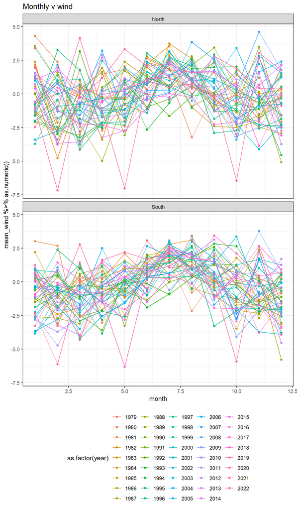

##### 4.1.3.1.1 Test correlation with recruitment index from the 2019 assessment model

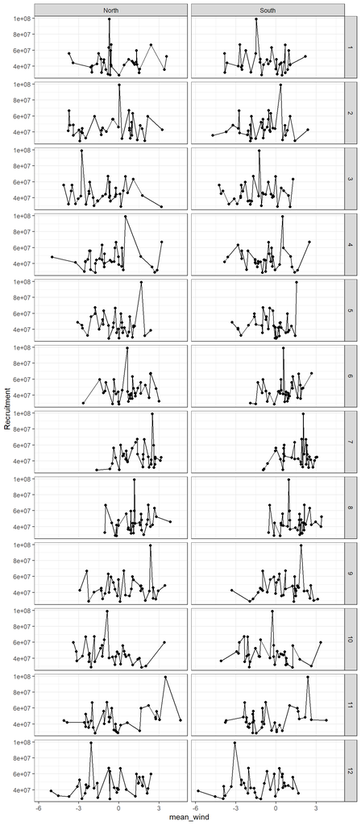

#### 4.1.3.2 u wind

Positive u wind = wind is blowing to the east

```
##         names          mean_wind          min_wind           max_wind
## 1 X1979.01.01   1.45269603729248  1.29819440841675   1.57005679607391
## 2 X1979.02.01   2.63577941656113  1.98740470409393   3.57330727577209
## 3 X1979.03.01   4.12896010875702  3.96217894554138   4.27426958084106
## 4 X1979.04.01 -0.956579941511154 -1.30267691612244 -0.527709543704987
## 5 X1979.05.01  0.362831687927246 0.299994617700577  0.479556113481522
## 6 X1979.06.01   3.60882782936096  3.23824834823608   3.94925093650818
```

```
##         names         mean_wind           min_wind          max_wind
## 1 X1979.01.01  1.38577417532603  0.670989215373993  1.90876638889313
## 2 X1979.02.01  3.35631279945374   1.98196387290955  5.00613355636597
## 3 X1979.03.01  2.57121164798737   1.23079669475555  3.95357894897461
## 4 X1979.04.01 0.616446284453074 -0.510847508907318  1.37352740764618
## 5 X1979.05.01 0.527386673291524  0.396705806255341 0.648249387741089
## 6 X1979.06.01  2.52984784444173   1.16936814785004  3.22574830055237
```

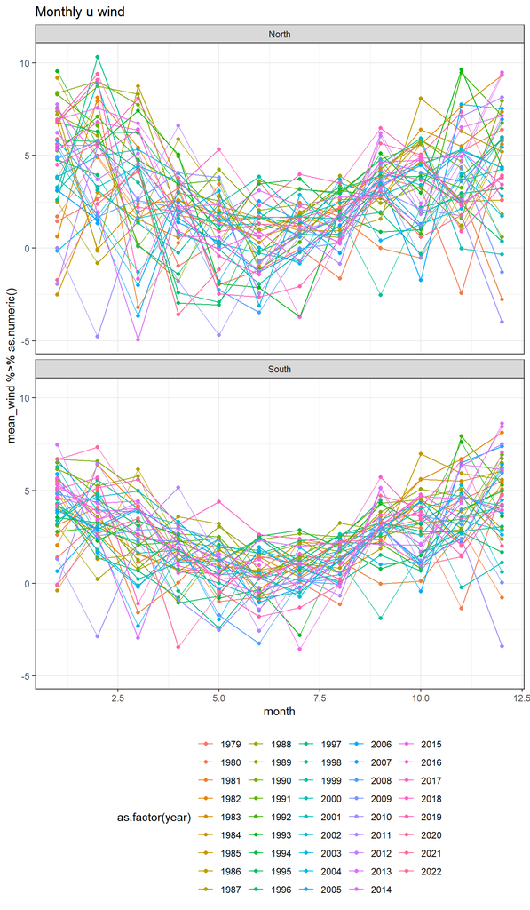

##### 4.1.3.2.1 Test correlation with recruitment index from the 2019 assessment model

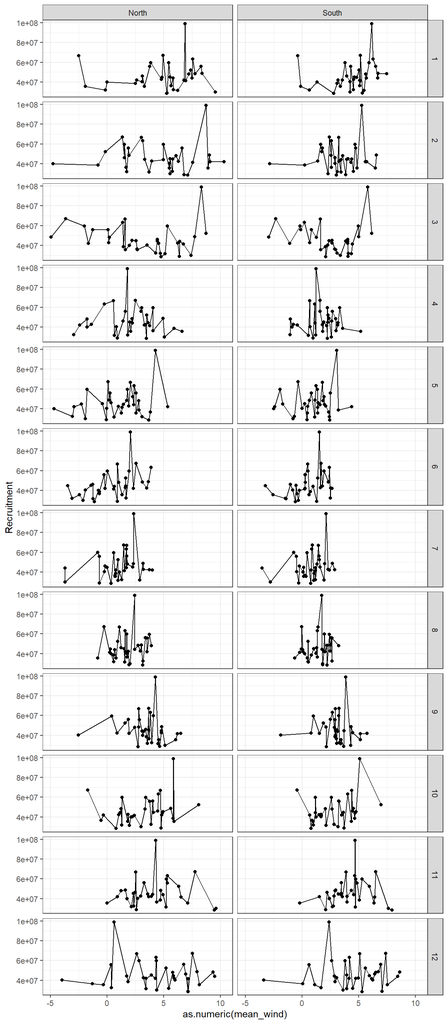